# Track Analysis Methods

Inge Wortel

2021-07-07

# Introduction

This tutorial provides an overview of how to perform popular analysis methods and visualizations commonly applied to tracking data. Examples range from the simple analysis of speed or other measures on single tracks, to the application of step-based or staggered metrics, to the generation of autocorrelation plots and performing angle analyses.

# Datasets

First load the package:

```r
library( celltrackR )
library( ggplot2 )
```

The package contains a dataset of B and T cells in a mouse cervical lymph node, and neutrophils responding to an *S.aureus* infection in a mouse ear, all imaged using two-photon microscopy. While the original data contained 3D coordinates, we’ll use the 2D projection on the XY plane (see the vignettes on quality control methods and preprocessing of the package datasets for details). We will here use this dataset as an example of how to apply analysis metrics.

For example, the T-cell dataset consists of 199 tracks of individual cells in a tracks object:

```r
str( TCells, list.len = 1 )
```

```
## List of 199
##  $ 1     : num [1:39, 1:3] 48 72 96 120 144 168 192 216 240 264 ...
##   ..- attr(*, "dimnames")=List of 2
##   .. ..$ : NULL
##   .. .. [list output truncated]
##   [list output truncated]
##  - attr(*, "class")= chr "tracks"
```

Each element in this list is a track from a single cell, consisting of a matrix with $(x,y)$ coordinates and the corresponding measurement timepoints:

```r
head( TCells[[1]] )
```

```
##        t       x       y
## [1,]  48 90.8534 65.3943
## [2,]  72 89.5923 64.9042
## [3,]  96 88.6958 67.1125
## [4,] 120 87.3437 68.2392
## [5,] 144 86.2740 67.9236
## [6,] 168 84.0549 68.2502
```

Similarly, we will also use the `BCells` and `Neutrophils` data:

```r
str( BCells, list.len = 1 )
```

```
## List of 74
##  $ 130  : num [1:24, 1:3] 48 72 96 120 144 168 192 216 240 264 ...
##   ..- attr(*, "dimnames")=List of 2
##   .. ..$ : NULL
##   .. .. [list output truncated]
##   [list output truncated]
##  - attr(*, "class")= chr "tracks"
```

```r
str( Neutrophils, list.len = 1 )
```

```
## List of 411
##  $ 21     : num [1:7, 1:3] 48 72 96 120 144 ...
##   ..- attr(*, "dimnames")=List of 2
##   .. ..$ : NULL
##   .. .. [list output truncated]
##   [list output truncated]
##  - attr(*, "class")= chr "tracks"
```

For the purpose of this tutorial, we’ll just sample a subset from these datasets (Normally you would not do this, but it will help here to speed things up and to avoid cluttered plots; the same methods would apply to a full dataset).

```r
# for reproducibility
set.seed(2021)

# sample names, sort them in numeric order, and use them to subset the tracks
Bsample <- sample( names(BCells),50)
BCells2 <- BCells[ Bsample ]

# same for the T cells
Tsample <- sample( names(TCells),50)
TCells2 <- TCells[ Tsample ]

# and the neutrophils
Nsample <- sample( names(Neutrophils),50)
Neutrophils2 <- Neutrophils[ Nsample ]
```

# 1 Simple track visualization

### 1.1 2D and 3D plotting

The standard plotting method for tracks plots the projection of tracks on the $(x,y)$ plane (if tracks are in 3D, the z-coordinate is ignored to obtain a projection):

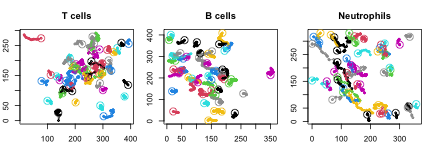

```r
par( mfrow = c(1,3), mar = c(2,2,3,1)+0.1 )
plot( TCells2, main = "T cells" )
plot( BCells2, main = "B cells" )
plot( Neutrophils2, main = "Neutrophils" )
```

We can also plot 3D tracks using the function `plot3d()` (which requires the package `scatterplot3d`):

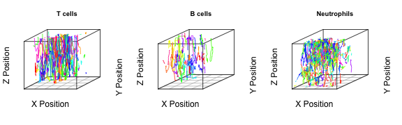

```r
# load original, 3D tracks as an example, since the processed tracks are 2D
load( system.file("extdata", "TCellsRaw.rda", package="celltrackR" ) )
load( system.file("extdata", "BCellsRaw.rda", package="celltrackR" ) )
load( system.file("extdata", "NeutrophilsRaw.rda", package="celltrackR" ) )

# omit axes and labels to save space here;
par( mfrow = c(1,3), mar = c(0,0,2,0) + 0.1 )
plot3d( TCellsRaw, main = "T cells", tick.marks = FALSE )
plot3d( BCellsRaw, main = "B cells", tick.marks = FALSE )
plot3d( NeutrophilsRaw, main = "Neutrophils", tick.marks = FALSE )
```

### 1.2 Star plots (Rose plots)

Finally, we can overlay the track starting points using `normalizeTracks()` – which is useful to detect directionality:

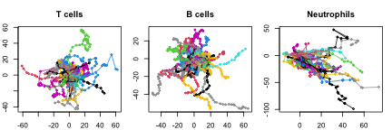

```r
par( mfrow = c(1,3), mar = c(2,2,3,1)+0.1 )
plot( normalizeTracks(TCells2), main = "T cells" )
plot( normalizeTracks(BCells2), main = "B cells" )
plot( normalizeTracks(Neutrophils2), main = "Neutrophils" )
```

# 2 Quantification of measures on tracks

The package contains several measures that can be computed on single tracks (see `?TrackMeasures` for an overview). The following sections will give examples on how to compute these metrics in different ways, using the `speed()` function as an example.

### 2.1 Cell-based analyses

To compute a metric for each track in a dataset, use R’s `sapply()` function directly on the tracks object:

```r
# Obtain mean speeds for each track using sapply
Tcell.speeds <- sapply( TCells2, speed )
str( Tcell.speeds )
```

```
##  Named num [1:50] 0.0804 0.2038 0.0873 0.2824 0.1394 ...
##  - attr(*, "names")= chr [1:50] "25" "5828_2" "8793" "6782" ...
```

```r
summary( Tcell.speeds )
```

```
##    Min. 1st Qu.  Median    Mean 3rd Qu.    Max.
## 0.04102 0.09340 0.13911 0.14266 0.19052 0.28240
```

```r
hist( Tcell.speeds )
```

[output not shown]

Now let’s repeat for the other two celltypes and plot them next to each other for comparison

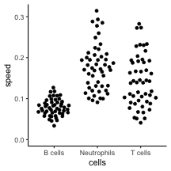

```r
Bcell.speeds <- sapply( BCells2, speed )
Nphil.speeds <- sapply( Neutrophils2, speed )

# Create a dataframe of all data
dT <- data.frame( cells = "T cells", speed = Tcell.speeds )
dB <- data.frame( cells = "B cells", speed = Bcell.speeds )
dN <- data.frame( cells = "Neutrophils", speed = Nphil.speeds )
d <- rbind( dT, dB, dN )

# Compare:
ggplot( d, aes( x = cells, y = speed ) ) +
  ggbeeswarm::geom_quasirandom() +
  scale_y_continuous( limits = c(0,NA) ) +
  theme_classic()
```

### 2.2 Step-based analyses

It has been suggested that cell-based analyses introduce biases, and that analyses should be performed on individual “steps” from all tracks combined instead ([Beltman et al (2009)](https://www.ncbi.nlm.nih.gov/pubmed/19834485)).

We can extract such steps using the `subtracks()` function (where `i` is the subtrack length, which is 1 for a single step):

```r
Tcell.steps <- subtracks( TCells2, i = 1 )
```

We can then proceed as before to obtain speeds for each step and further summary statistics:

```r
# Obtain instantaneous speeds for each step using sapply
Tcell.step.speeds <- sapply( Tcell.steps, speed )
str( Tcell.step.speeds )
```

```
##  Named num [1:988] 0.1364 0.1223 0.057 0.2002 0.0684 ...
##  - attr(*, "names")= chr [1:988] "25.1" "25.2" "25.3" "25.4" ...
```

```r
summary( Tcell.step.speeds )
```

```
##     Min.  1st Qu.   Median     Mean  3rd Qu.     Max.
## 0.002167 0.047966 0.090478 0.127717 0.160476 0.868418
```

Compare cell-based versus step-based:

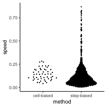

```r
d.step <- data.frame( method = "step-based", speed = Tcell.step.speeds )
d.cell <- data.frame( method = "cell-based", speed = Tcell.speeds )
d.method <- rbind( d.step, d.cell )

ggplot( d.method, aes( x = method, y = speed ) ) +
  ggbeeswarm::geom_quasirandom( size = 0.3 ) +
  scale_y_continuous( limits = c(0,NA) ) +
  theme_classic()
```

And again compare between the different celltypes:

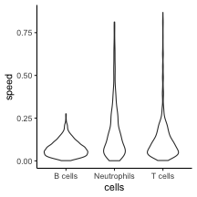

```r
Bcell.step.speeds <- sapply( subtracks(BCells2,1), speed )
Nphil.step.speeds <- sapply( subtracks(Neutrophils2,1), speed )

# Create a dataframe of all data
dT <- data.frame( cells = "T cells", speed = Tcell.step.speeds )
dB <- data.frame( cells = "B cells", speed = Bcell.step.speeds )
dN <- data.frame( cells = "Neutrophils", speed = Nphil.step.speeds )
dstep <- rbind( dT, dB, dN )

# Compare (violin plot now because there are many individual steps)
ggplot( dstep, aes( x = cells, y = speed ) ) +
  geom_violin() +
  #ggbeeswarm::geom_quasirandom( size = 0.3 ) +
  scale_y_continuous( limits = c(0,NA) ) +
  theme_classic()
```

Note that we can do something similar for turning angles, but we need at least two steps to compute a turning angle. Therefore, use `subtracks()` with `i=2` in combination with the `overallAngle()` method:

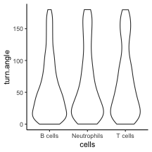

```r
Tcell.step.angle <- sapply( subtracks(TCells2,2), overallAngle )
Bcell.step.angle <- sapply( subtracks(BCells2,2), overallAngle )
Nphil.step.angle <- sapply( subtracks(Neutrophils2,2), overallAngle )

# Create a dataframe of all data
dT <- data.frame( cells = "T cells", turn.angle = Tcell.step.angle )
dB <- data.frame( cells = "B cells", turn.angle = Bcell.step.angle )
dN <- data.frame( cells = "Neutrophils", turn.angle = Nphil.step.angle )
dangle <- rbind( dT, dB, dN )

# convert radians to degrees
dangle$turn.angle <- pracma::rad2deg( dangle$turn.angle )

# Compare:
ggplot( dangle, aes( x = cells, y = turn.angle ) ) +
  #ggbeeswarm::geom_quasirandom( size = 0.3 ) +
  geom_violin() +
  scale_y_continuous( limits = c(0,NA) ) +
  theme_classic()
```